# Part 8: Monte Carlo Simulations

D. Gillespie algorithm

Mingyang Lu

08/22/2023

# Intro

Here, we will discuss to use Gillepie algorithm to simulate the stochastic dynamics of a chemical reaction network. First, we setup a vector $\mathbf{S}$ to represent the state of the system, composed of the number of molecules of each species. For each chemical reaction $j$,

$$\sum_i^{n_s}{\alpha_{ij}S_i}
\rightarrow \sum_i^{n_s}{\beta_{ij}S_i}$$
where $n_S$ is the total number of species.

Second, we define the stoichiometry matrix $\Gamma$, where each element $\Gamma_{ij} = \beta_{ij} - \alpha_{ij}$. The stoichiometry vector $\mathbf{\gamma_j}$ for each reaction $j$ is the $j^th$ column vector of $\Gamma$.

Third, we define the reaction propensity $R_j$ as the product of its specific probability rate (from the law of mass action, $R_j = k_j \Pi_{i=1}^{n_S} S_i^{\alpha_{ij}}$) and its reaction degeneracy (see reference).

# Workflow for Gillespie algorithm

**1.** Set the initial state $\mathbf{S}$ and initialize time $t$ to 0.

**2.** Calculate the reaction propensities $R_j(S)$

**3.** Randomly pick a reaction j based on $R_j(S)$

**4.** Randomly pick the waiting time $\tau$ based on $R_{tot} = \sum_{j}{R_j(\mathbf{S})}$

**5.** Increment the simulation time $t \rightarrow t + \tau$

**6.** Update the state $\mathbf{S} \rightarrow \mathbf{S} + \mathbf{\gamma_j}$ reflect the fact that reaction j has occurred.

**7.** Return to step 2.

The following is a generic implementation of the Gillespie algorithm in R.

```r
# A generic Gillespie algorithm for one iteration
gillespie_step <- function(t,Xs,propensity, stoichiometry,...){
  p_all = propensity(Xs, ...)  # propensity
  p_sum = sum(p_all)
  if(abs(p_sum) < 10^-9){   # if p_sum = 0, simulation stops
    return(list(t = t, Xs = Xs, if_stop = TRUE))
  }
  dt = rexp(1,rate=sum(p_all))  # compute the waiting wait from an exponential distribution
  event = sample(length(p_all),size=1,prob=p_all)   # choose the event
  dx = stoichiometry(event, ...) #  find the stoichiometry vector corresponding to the selected reaction
  t_new = t + dt
  Xs_new = Xs + dx
  return(list(t = t_new, Xs = Xs_new, if_stop = FALSE))  #output: new t, new Xs
}

# the Gillespie simulation
# Users need to specify:
# (1) the initial state X0 (a vector of n species)
# (2) maximum time (tmax)
# (3) maximum allowed iterations (iter_max)
# (4) other parameters required for the propensity (mostly kinetic rates)

ssa <- function(propensity,stoichiometry,X0,tmax,iter_max, ...){
  Xs = X0
  n = length(Xs)
  t_all = rep(NA, iter_max)
  X_all = matrix(NA, nrow = iter_max, ncol = n)

  t = 0
  iter = 1
  t_all[iter] = t
  X_all[iter,] = Xs
  if_stop = FALSE

  while(t < tmax & iter < iter_max){
    output <- gillespie_step(t,Xs,propensity, stoichiometry,...)
    if(output$if_stop)break
    iter = iter + 1
    t = output$t
    Xs = output$Xs
    t_all[iter] = t
    X_all[iter,] = Xs
  }
  return(cbind(t_all, X_all))
}
```

In the following, we provide a few examples of its usage.

# 1: A gene constitutively transcribed

We consider a gene $x$ with transcriptional rate $g$ and degradation rate $k$.

$$0 {\stackrel{g}{\rightarrow}} x
{\stackrel{k}{\rightarrow}} 0$$

The corresponding ODE of the system is

$$\frac{dx}{dt} = g - kx$$
The stochastic dynamics is a typical birth-death process.

```r
# specify propensity functions
p_func1 <- function(Xs,g,k) {   # Xs: current state; k1, k2 ...: parameters
  x = Xs[1]
  return(c(g,k*x))   #output: a vector of propensity
}

# specify stoichiometry matrix
s_func1 <- function(r_ind,g,k) {   # r_ind: the choice of the reaction
  s_matrix = cbind(c(1),    # x adds 1
               c(-1))   # x subtracts 1
  return(s_matrix[,r_ind])
}
```

We first check the stochastic dynamics near the stable steady state in the deterministic scenario. The the following, we select $g = 100$ and $k = 0.1$. The deterministic steady state is $\bar{x} = g/k = 1000$. We set $x(t = 0) = \bar{x} = 1000$

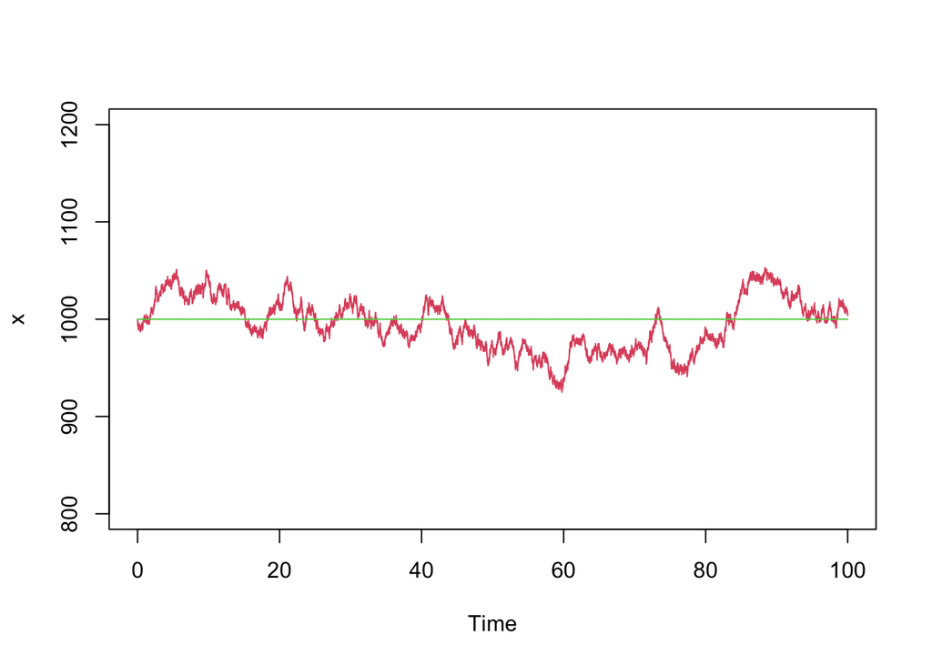

```r
g = 100; k = 0.1
set.seed(101)
X0 = c(1000)
tmax = 100
iter_max = 20000
results_1 = ssa(p_func1, s_func1, X0, tmax,iter_max, g = g, k = k)

plot(results_1[,1], results_1[,2], type = "s", col=2,
    xlab="Time", ylab="x", xlim=c(0,tmax), ylim=c(800,1200))
lines(results_1[,1], rep(X0,times = nrow(results_1)), col = 3)
```

Now if we set $g = 10$ and $k = 0.1$. $x(t = 0) = \bar{x} = 100$.

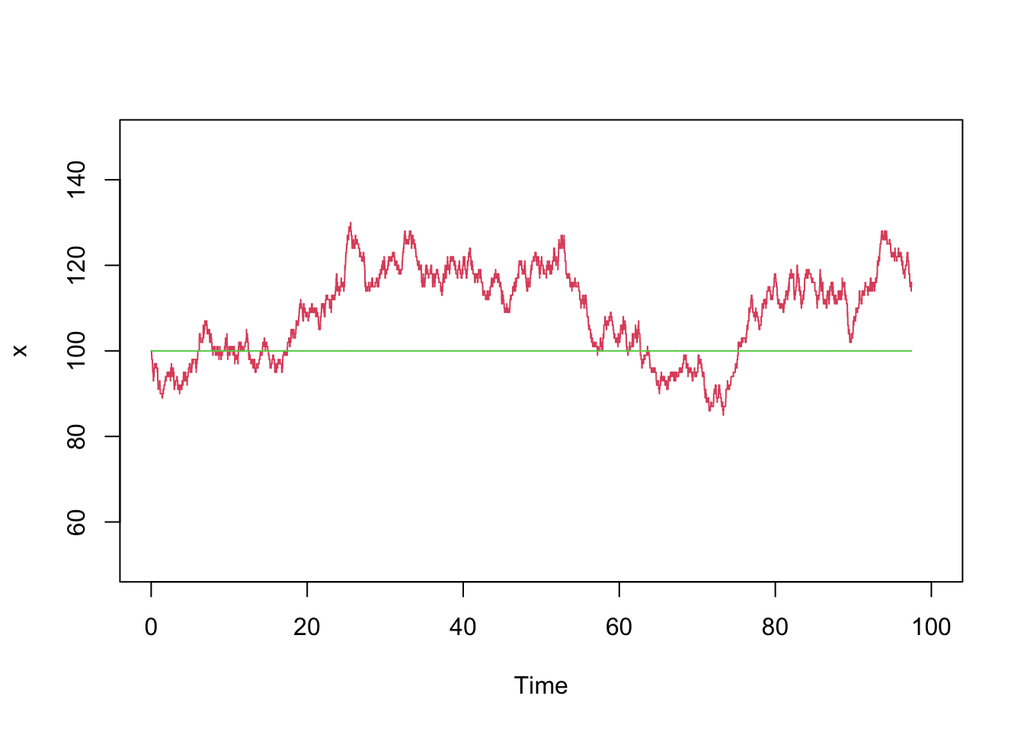

```r
g = 10; k = 0.1
set.seed(101)
X0 = c(100)
tmax = 100
iter_max = 2000
results_2 = ssa(p_func1, s_func1, X0, tmax,iter_max, g = g, k = k)

plot(results_2[,1], results_2[,2], type = "s", col=2,
    xlab="Time", ylab="x", xlim=c(0,tmax), ylim=c(50,150))
lines(results_2[,1], rep(X0,times = nrow(results_2)), col = 3)
```

We then set $g = 1$ and $k = 0.1$. $x(t = 0) = \bar{x} = 10$.

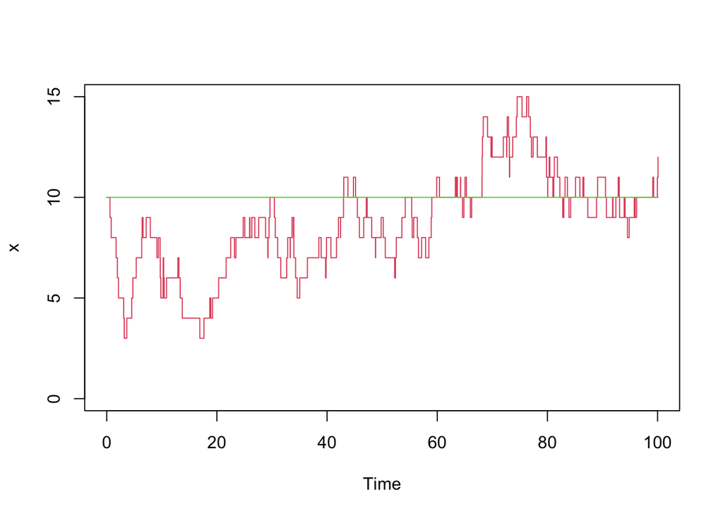

```r
g = 1; k = 0.1
set.seed(101)
X0 = c(10)
tmax = 100
iter_max = 2000
results_3 = ssa(p_func1, s_func1, X0, tmax,iter_max, g = g, k = k)
plot(results_3[,1], results_3[,2], type = "s", col=2,
    xlab="Time", ylab="x", xlim=c(0,tmax), ylim=c(0,15))
lines(results_3[,1], rep(X0,times = nrow(results_3)), col = 3)
```

We now evaluate the mean and standard deviation (SD) of $x$ for each simulation.

$$Mean(x) = \frac{\sum_{i=1}^{N}
x(t_i)\Delta t_i}{\sum_{i=1}^{N} \Delta t_i}$$
$$Mean(x^2) = \frac{\sum_{i=1}^{N} x(t_i)^2\Delta
t_i}{\sum_{i=1}^{N} \Delta t_i}$$
$$SD(x) = \frac{\sum_{i=1}^{N}
[x(t_i)-Mean(x)]^2\Delta t_i}{\sum_{i=1}^{N} \Delta t_i}$$
But the simplest way is to first compute $Mean(x)$ and $Mean(x^2)$, then obtain $SD(x)$ from

$$SD(x) = \sqrt{Mean(x^2) -
Mean(x)^2}$$

Often, we also evaluate the relative error (SD normalized by the mean value). Pay attention that it is incorrect to directly apply $sd()$ and $mean()$ functions to the results matrix, as the waiting times $\Delta t_i$ is not a constant. Also, if we only need to compute the statistics for mean, variance, standard deviations, *etc.*, we can do the calculations for $\sum_{i=1}^{N} x(t_i)\Delta t_i$, $\sum_{i=1}^{N} [x(t_i)-Mean(x)]^2\Delta t_i$, and $\sum_{i=1}^{N} \Delta t_i$ during the stochastic simulation. And the time trajectories (*i.e.*, the whole result matrix does not need to be stored).

```r
cal_stat <- function(results_mat) {    # results_mat: 1st column: t, 2nd - (n+1)th columns: n variables for each t
  mat = na.omit(results_mat)
  nt = nrow(mat)
  nx = ncol(mat)
  dt = mat[-1,1] - mat[1:(nt-1),1]
  t_tot = sum(dt)
  mean = t(mat[1:(nt-1),2:nx]) %*% dt / t_tot
  mean2 = t(mat[1:(nt-1),2:nx])**2 %*% dt / t_tot
  sd = sqrt(mean2 - mean**2)
  error = sd/mean
  return(list(mean = mean, sd = sd, error = error))
}
```

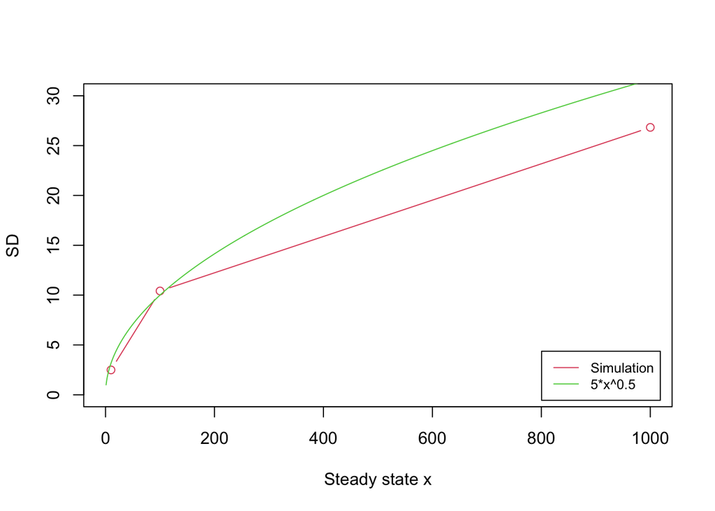

```r
ss_all = c(1000,100,10)
stat1 = cal_stat(results_1)
stat2 = cal_stat(results_2)
stat3 = cal_stat(results_3)

x_1 = seq(1,1000,1)
plot(ss_all, c(stat1$sd, stat2$sd, stat3$sd), type = "b", col = 2, xlab = "Steady state x", ylab ="SD", xlim = c(0,1000), ylim = c(0,30))
lines(x_1, x_1**0.5, type = "l", col = 3)
legend("bottomright", inset=0.02, legend = c("Simulation", "5*x^0.5"),
       col=2:4, lty=1, cex=0.8)
```

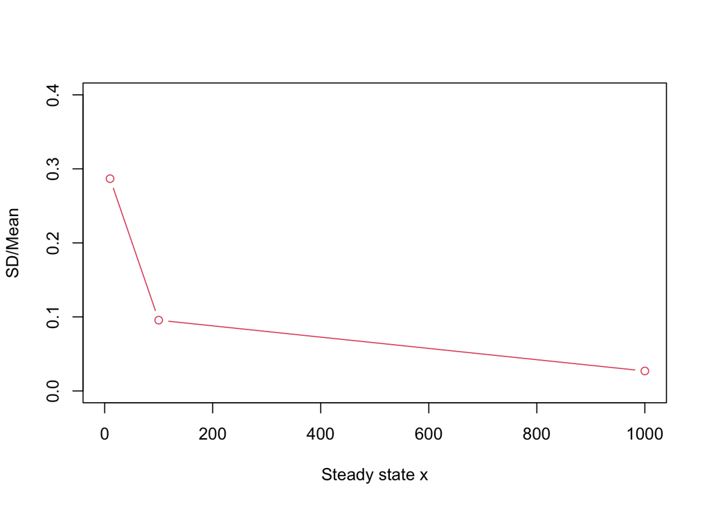

```r
plot(ss_all, c(stat1$error, stat2$error, stat3$error), type = "b", col = 2, xlab = "Steady state x", ylab ="SD/Mean",
     xlim = c(0,1000), ylim = c(0, 0.4))
```

Now, let’s consider the same systems for the above three conditions but starting from the zero initial condition. The purpose is to evaluate the growing dynamics towards the steady state.

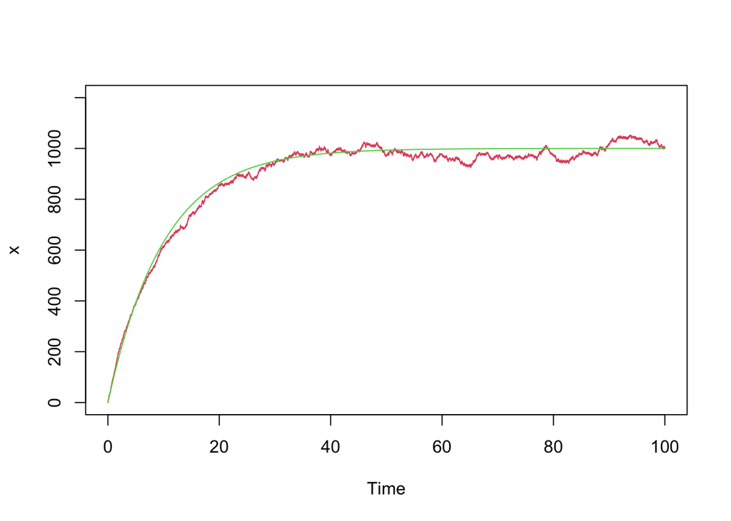

```r
g = 100; k = 0.1
set.seed(101)
X0 = c(0)
tmax = 100
iter_max = 20000
results_1 = ssa(p_func1, s_func1, X0, tmax,iter_max, g = g, k = k)

plot(results_1[,1], results_1[,2], type = "s", col=2,
    xlab="Time", ylab="x", xlim=c(0,tmax), ylim=c(0,1200))
x_1 = results_1[,1]
lines(x_1, g/k*(1-exp(-k*x_1)), col = 3)
```

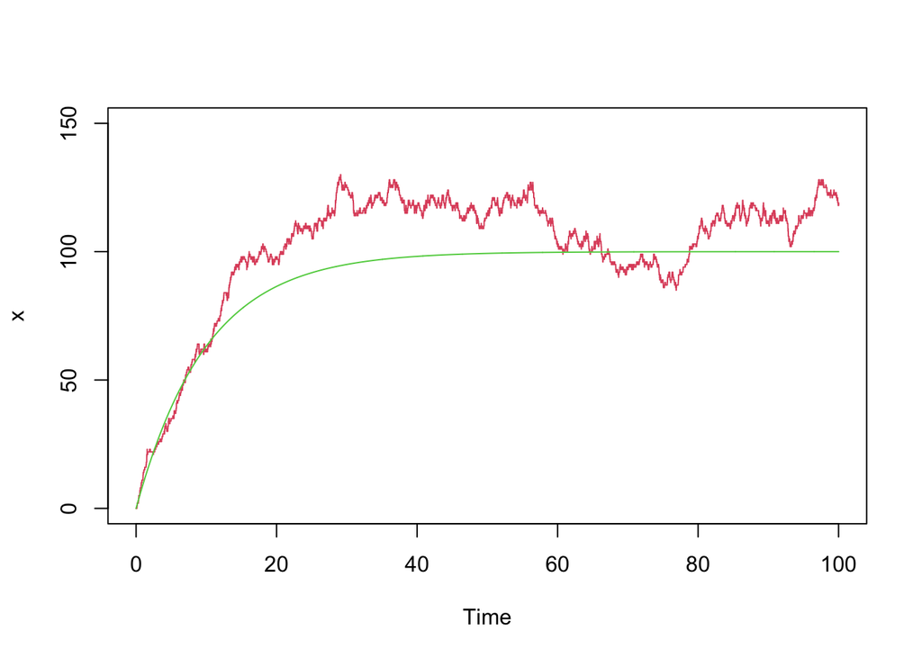

```r
g = 10; k = 0.1
set.seed(101)
X0 = c(0)
tmax = 100
iter_max = 2000
results_2 = ssa(p_func1, s_func1, X0, tmax,iter_max, g = g, k = k)

plot(results_2[,1], results_2[,2], type = "s", col=2,
    xlab="Time", ylab="x", xlim=c(0,tmax), ylim=c(0,150))
x_2 = results_2[,1]
lines(x_2, g/k*(1-exp(-k*x_2)), col = 3)
```

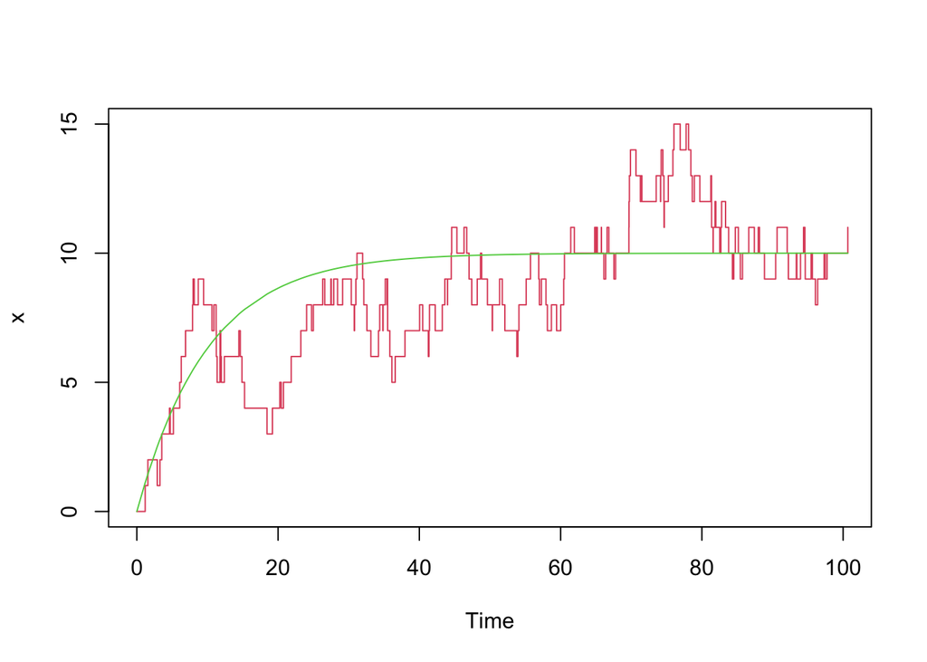

```r
g = 1; k = 0.1
set.seed(101)
X0 = c(0)
tmax = 100
iter_max = 2000
results_3 = ssa(p_func1, s_func1, X0, tmax,iter_max, g = g, k = k)
plot(results_3[,1], results_3[,2], type = "s", col=2,
    xlab="Time", ylab="x", xlim=c(0,tmax), ylim=c(0,15))
x_3 = results_3[,1]
lines(x_3, g/k*(1-exp(-k*x_3)), col = 3)
```

# 2: Bursting transcription

We consider a gene $x$ with transcriptional rate $g/n$, but n molecules every reaction, and degradation rate $k$.

$$0 {\stackrel{g/n}{\rightarrow}}
nx$$

$$x {\stackrel{k}{\rightarrow}} 0$$

The corresponding ODE of the system is

$$\frac{dx}{dt} = ng/n - kx = g -
kx$$

```r
# specify propensity functions
p_func2 <- function(Xs,g,k,n) {   # Xs: current state; k1, k2 ...: parameters
  x = Xs[1]
  return(c(g/n,k*x))   #output: a vector of propensity
}

# specify stoichiometry matrix
s_func2 <- function(r_ind,g,k,n) {   # r_ind: the choice of the reaction
  s_matrix = cbind(c(n),    # x adds n
               c(-1))   # x subtracts 1
  return(s_matrix[,r_ind])
}
```

We check the stochastic dynamics near the stable steady state in the deterministic scenario. We start with $g = 16$, $k = 0.1$, and $n = 1$. The deterministic steady state is $\bar{x} = g/k = 160$. We set $x(t = 0) = \bar{x} = 160$

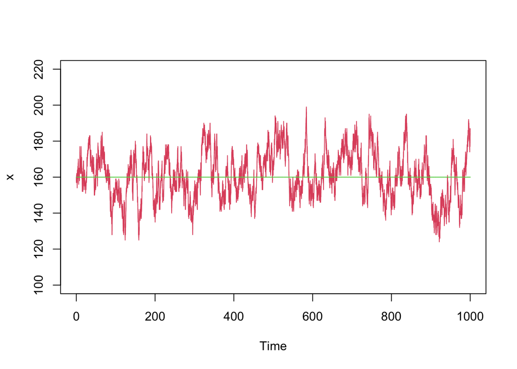

```r
set.seed(91)
g = 16; k = 0.1; n = 1
X0 = c(160)
tmax = 1000
iter_max = 50000
results_4 = ssa(p_func2, s_func2, X0, tmax,iter_max, g = g, k = k, n = n)

plot(results_4[,1], results_4[,2], type = "s", col=2,
    xlab="Time", ylab="x", xlim=c(0,tmax), ylim=c(100,220))
lines(results_4[,1], rep(X0,times = nrow(results_4)), col = 3)
```

Now if we set $g = 16$, $k = 0.1$, and $n = 2$. The steady state level remains the same. $x(t = 0) = \bar{x} = 160$.

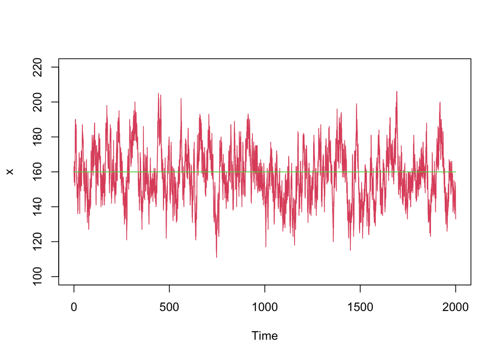

```r
g = 16; k = 0.1; n = 2
X0 = c(160)
tmax = 2000
iter_max = 500000
results_5 = ssa(p_func2, s_func2, X0, tmax,iter_max, g = g, k = k, n = n)

plot(results_5[,1], results_5[,2], type = "s", col=2,
    xlab="Time", ylab="x", xlim=c(0,tmax), ylim=c(100,220))
lines(results_5[,1], rep(X0,times = nrow(results_5)), col = 3)
```

We then set $g = 16$, $k = 0.1$, $n = 4$. $x(t = 0) = \bar{x} = 160$.

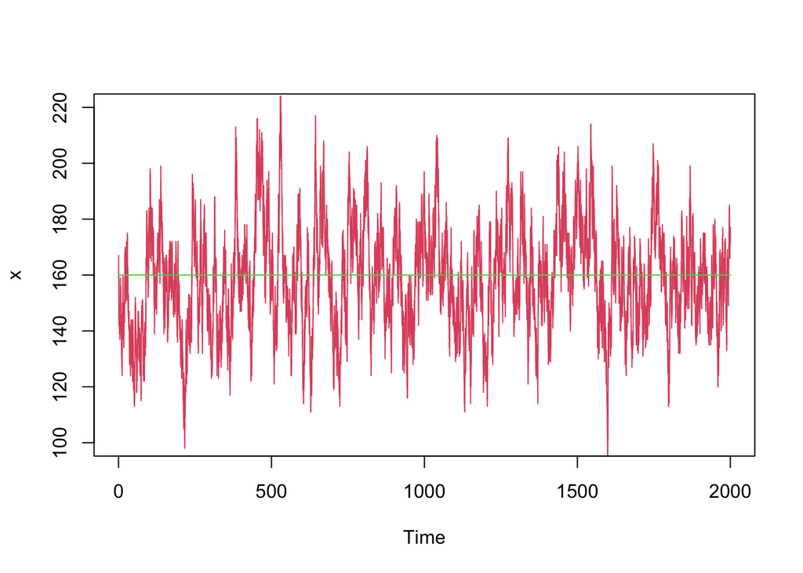

```r
g = 16; k = 0.1; n = 4
X0 = c(160)
tmax = 2000
iter_max = 500000
results_6 = ssa(p_func2, s_func2, X0, tmax,iter_max, g = g, k = k, n = n)
plot(results_6[,1], results_6[,2], type = "s", col=2,
    xlab="Time", ylab="x", xlim=c(0,tmax), ylim=c(100,220))
lines(results_6[,1], rep(X0,times = nrow(results_6)), col = 3)
```

We then set $g = 16$, $k = 0.1$, $n = 8$. $x(t = 0) = \bar{x} = 160$.

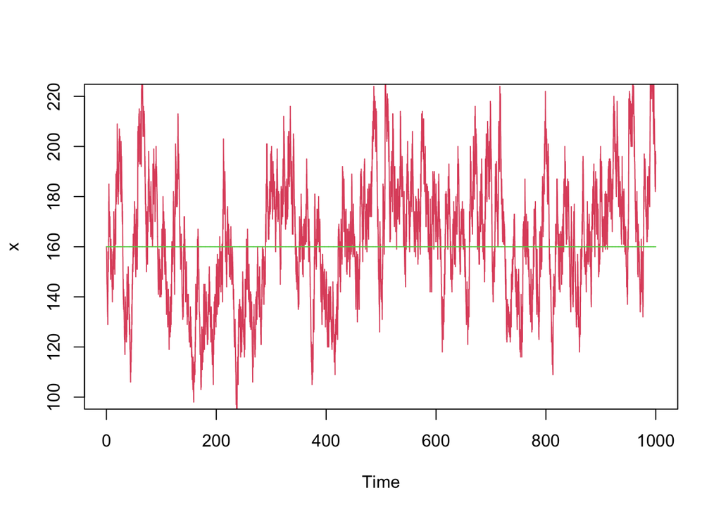

```r
g = 16; k = 0.1; n = 8
X0 = c(160)
tmax = 1000
iter_max = 500000
results_7 = ssa(p_func2, s_func2, X0, tmax,iter_max, g = g, k = k, n = n)
plot(results_7[,1], results_7[,2], type = "s", col=2,
    xlab="Time", ylab="x", xlim=c(0,tmax), ylim=c(100,220))
lines(results_7[,1], rep(X0,times = nrow(results_7)), col = 3)
```

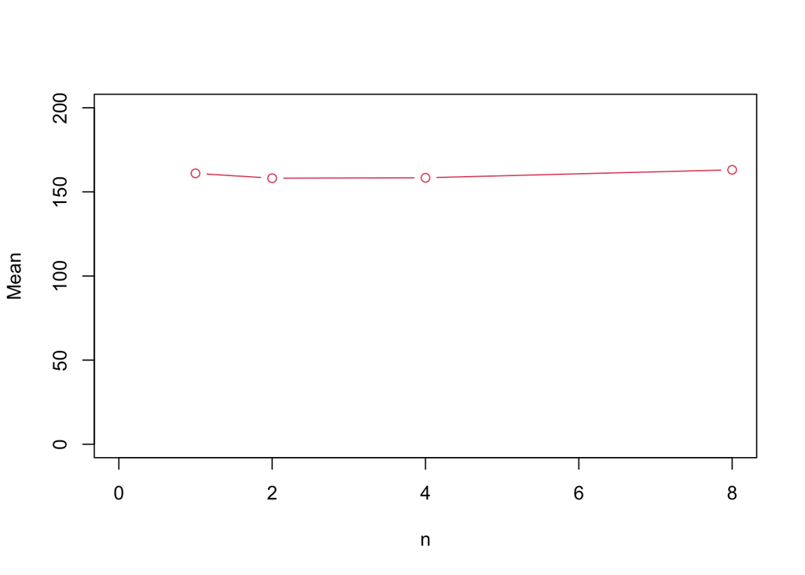

```r
n_all = c(1,2,4,8)
stat4 = cal_stat(results_4)
stat5 = cal_stat(results_5)
stat6 = cal_stat(results_6)
stat7 = cal_stat(results_7)

plot(n_all, c(stat4$mean, stat5$mean, stat6$mean, stat7$mean), type = "b", col = 2, xlab = "n", ylab ="Mean", xlim = c(0,8), ylim = c(0,200))
```

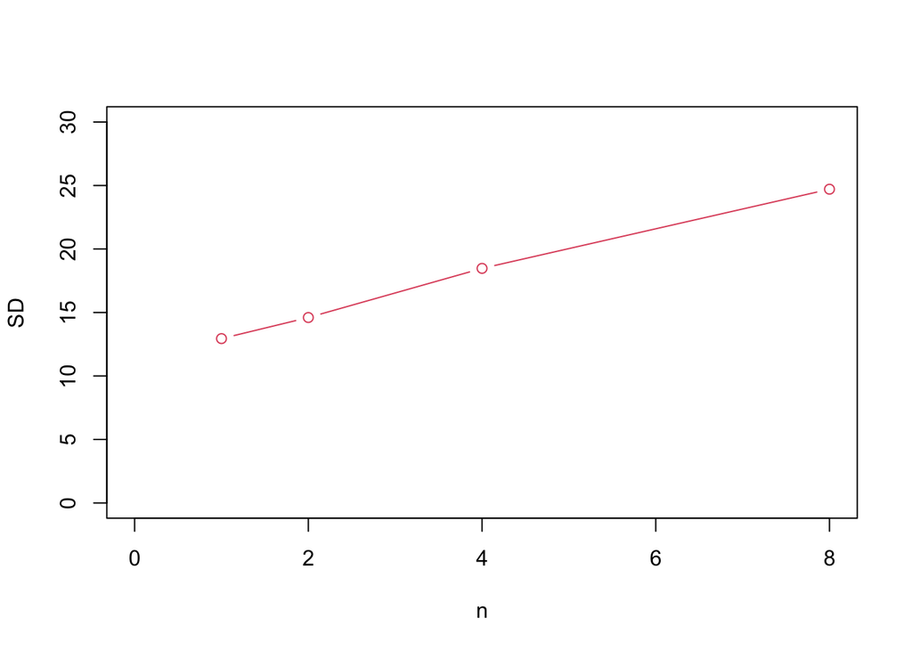

```r
plot(n_all, c(stat4$sd, stat5$sd, stat6$sd, stat7$sd), type = "b", col = 2, xlab = "n", ylab ="SD", xlim = c(0,8), ylim = c(0,30))
```

# 3: Stochastic dynamics of a self-inhibiting gene

We consider a model of a self-inhibiting gene. The model is the same as the previous model for a self-activating gene, but with the opposite $g_0$ and $g_1$.

```r
# specify propensity functions
p_func3 <- function(Xs,g0,g1,k,kon,koff) {   # Xs: current state; k1, k2 ...: parameters
  d = Xs[1] #D` (0: bound; 1: unbound)
  c = Xs[2] #C  (0: unbound; 1: bound)
  m = Xs[3] #M  (number of M)
  return(c(g0*d, k*m, kon*d*m*(m-1)/2, koff*c, g1*c))   #output: a vector of propensity
}

# specify stoichiometry matrix
s_func3 <- function(r_ind,g0,g1,k,kon,koff) {   # r_ind: the choice of the reaction
  s_matrix = cbind(c(0,0,1),    # M adds 1
                   c(0,0,-1),   # M subtracts 1
                   c(-1,1,-2),  # C adds 1, D subtracts 1, and M subtracts 2
                   c(1,-1,2),  # C subtracts 1, D adds 1, and M adds 2
                   c(0,0,1))  # M adds 1
  return(s_matrix[,r_ind])
}
```

We set $g_0 = 55$, $g_1 = 5$, $k = 0.1$, $k_{on} = 0.002$, $k_{off} = 90$. With this condition,$K = \sqrt{\frac{2k_{off}}{k_{on}}} = 300$. This is the scenario of high copy number and fast binding/unbinding.

For the initial condition, we first consider $D = 1$, $C = 0$, $M = 300$.

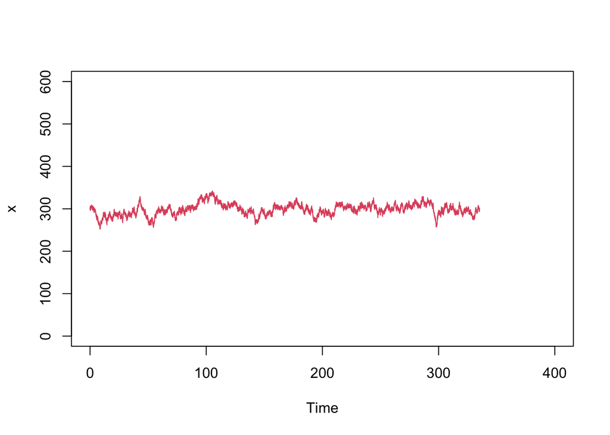

```r
set.seed(101)
g0 = 55; g1 = 5; k = 0.1; kon = 0.002; koff = 90
X0 = c(1,0,300)
tmax = 400
iter_max = 50000
results_8 = ssa(p_func3, s_func3, X0, tmax,iter_max, g0=g0, g1=g1, k=k, kon=kon, koff=koff)

# R: almost a constant; M: noisy because of low copy number of $M$
plot(results_8[,1], results_8[,4], type = "s", col=2,
    xlab="Time", ylab="x", xlim=c(0,tmax), ylim=c(0,600))
```

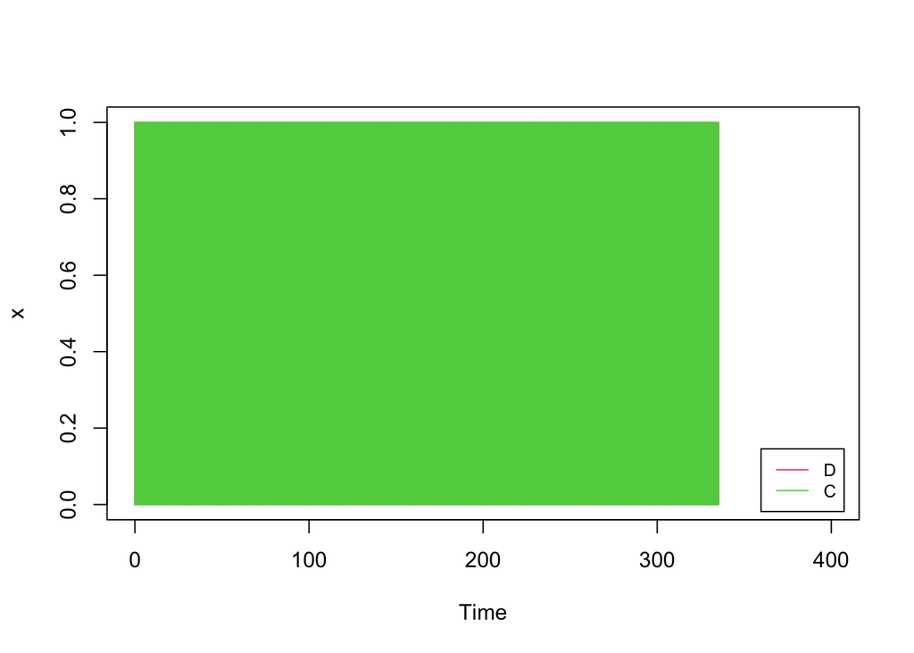

```r
# Plotting promoter occupancy
plot(results_8[,1], results_8[,2], type = "s", col=2,
    xlab="Time", ylab="x", xlim=c(0,tmax), ylim=c(0,1))
lines(results_8[,1],results_8[,3], type = "s", col = 3)
legend("bottomright", inset=0.02, legend = c("D", "C"),
       col=2:3, lty=1, cex=0.8)
```

```r
stat8 = cal_stat(results_8)
stat8$mean
```

```
##         [,1]
##    0.4997881
##    0.5002119
##  297.9263225
```

```r
stat8$sd
```

```
##      [,1]
##   0.50000
##   0.50000
##  13.62181
```

Now if we turn off the binding/unbinding ($k_{on} = k_{off} = 0$), and set $g_0 = 30$ so that the system has a similar steady state of $M$. This modified system is the same as a constitutively expressed gene.

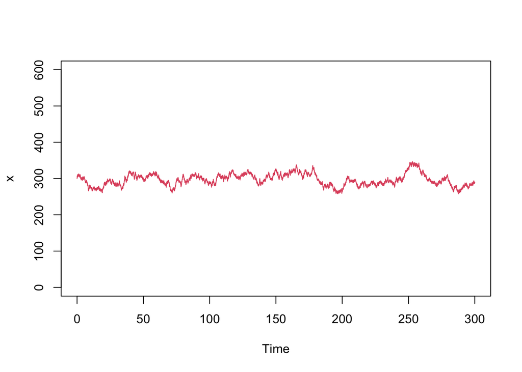

```r
set.seed(101)
g0 = 30; g1 = 30; k = 0.1; kon = 0.0; koff = 0
X0 = c(1,0,300)
tmax = 300
iter_max = 50000
results_9 = ssa(p_func3, s_func3, X0, tmax,iter_max, g0=g0, g1=g1, k=k, kon=kon, koff=koff)

# R: almost a constant; M: noisy because of low copy number of $M$
plot(results_9[,1], results_9[,4], type = "s", col=2,
    xlab="Time", ylab="x", xlim=c(0,tmax), ylim=c(0,600))
```

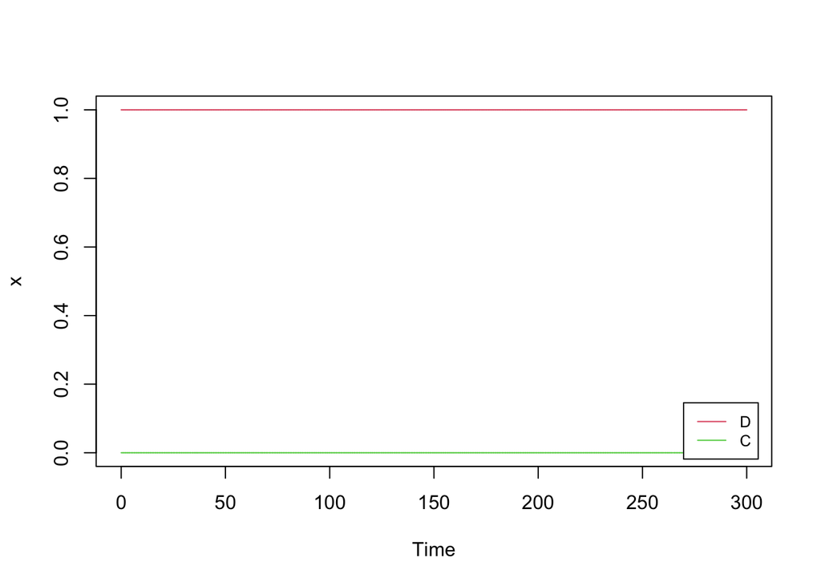

```r
# Plotting promoter occupancy
plot(results_9[,1], results_9[,2], type = "s", col=2,
    xlab="Time", ylab="x", xlim=c(0,tmax), ylim=c(0,1))
lines(results_9[,1],results_9[,3], type = "s", col = 3)
legend("bottomright", inset=0.02, legend = c("D", "C"),
       col=2:3, lty=1, cex=0.8)
```

```r
stat9 = cal_stat(results_9)
stat9$mean
```

```
##      [,1]
##    1.0000
##    0.0000
##  296.4816
```

```r
stat9$sd
```

```
##      [,1]
##   0.00000
##   0.00000
##  16.54486
```

Compared to the gene with self-inhibition, the noise level ($SD(M)$) is higher. It is well established that a self-inhibition reduces gene expression noise.

Now if we reduce the copy number of the system with the parameter set $g_0 = 5.5$, $g_1 = 0.5$, $k = 0.1$, $k_{on} = 0.2$, $k_{off} = 90$. With this condition,$K = \sqrt{\frac{2k_{off}}{k_{on}}} = 30$, and the initial condition $D = 1$, $C = 0$, $M = 30$.

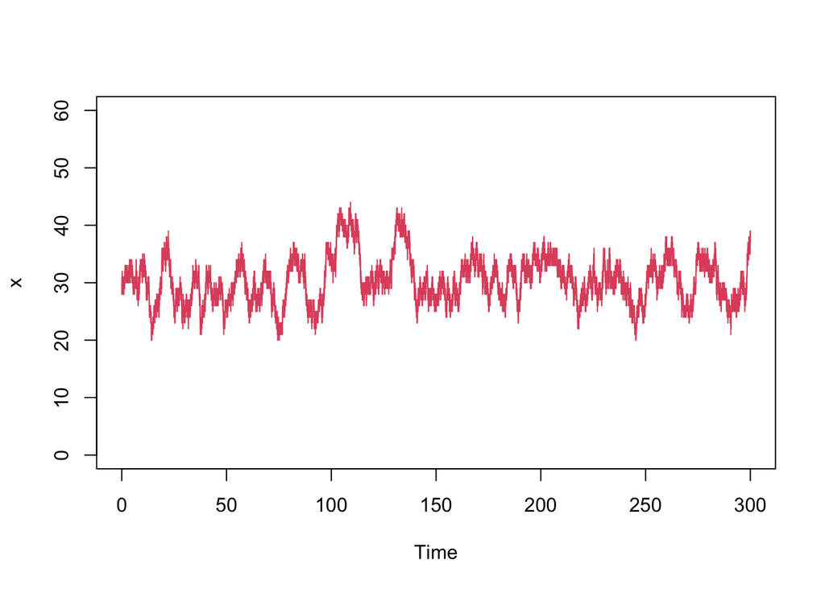

```r
set.seed(101)
g0 = 5.5; g1 = 0.5; k = 0.1; kon = 0.2; koff = 90
X0 = c(1,0,30)
tmax = 300
iter_max = 50000
results_10 = ssa(p_func3, s_func3, X0, tmax,iter_max, g0=g0, g1=g1, k=k, kon=kon, koff=koff)

# R: almost a constant; M: noisy because of low copy number of $M$
plot(results_10[,1], results_10[,4], type = "s", col=2,
    xlab="Time", ylab="x", xlim=c(0,tmax), ylim=c(0,60))
```

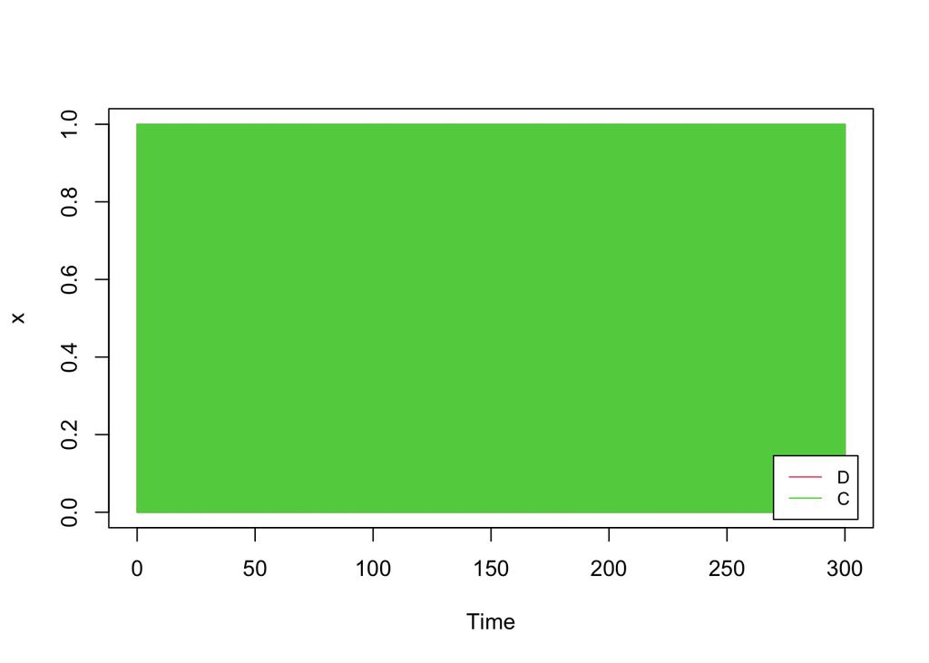

```r
# Plotting promoter occupancy
plot(results_10[,1], results_10[,2], type = "s", col=2,
    xlab="Time", ylab="x", xlim=c(0,tmax), ylim=c(0,1))
lines(results_10[,1],results_10[,3], type = "s", col = 3)
legend("bottomright", inset=0.02, legend = c("D", "C"),
       col=2:3, lty=1, cex=0.8)
```

```r
stat10 = cal_stat(results_10)
stat10$mean
```

```
##        [,1]
##   0.4997054
##   0.5002946
##  30.3419593
```

```r
stat10$sd
```

```
##       [,1]
##  0.4999999
##  0.4999999
##  3.9675863
```

The stochastic dynamcis resemble oscillatory dynamics.